# Proyecto Reglas Asociación

alumnos

## Qualitative Bankruptcy Data Set

Utilizaremos UNA VERSIÓN PARECIDA PERO NO IGUAL del conjunto de datos `Qualitative_Bankruptcy Data Set` del repositorio *UCI Machine Learning* para trabajar el estudio de las variables Categóricas/Cualitativas y la bondad de las reglas de Asociación para extraer conocimiento de un conjunto de datos, en este caso, predecir la bancarrota (*Bankruptcy*) en base a parámetros cuantitativos/cualitativos preparados por expertos.

Cargar el fichero `Qualitative_Bankruptcy.num.txt` y crear el `data.frame` `QB`.

```r
QB <- read.csv("./Qualitative_Bankruptcy.num.txt", header=FALSE)
```

Asigna nombres válidos a las columnas del `data.frame` (usa `make.names` para asegurarte que no contiene símbolos raros). Más información en el fichero `Qualitative_Bankruptcy.info.txt`

```r
colnames(QB) <- make.names(c("Industrial Risk", "Management Risk",
                               "Financial Flexibility","Credibility",
                               "Competitiveness", "Operating Risk",
                               "Bankruptcy"))
```

Se visualiza el dataframe cargado

```r
head(QB)
```

|  | Industrial.Risk | Management.Risk | Financial.Flexibility | Credibility | Competitiveness | Operating.Risk | Bankruptcy |
| --- | --- | --- | --- | --- | --- | --- | --- |
| 1 | 9.54873698 | 9.531917 | 5.335235 | 6.304893 | 5.741153 | 9.298113 | NB |
| 2 | 0.08713305 | 1.785630 | 4.517538 | 4.118767 | 4.399522 | 1.842645 | NB |
| 3 | 6.05525601 | 4.918437 | 4.322067 | 3.692966 | 3.738189 | 5.549685 | NB |
| 4 | 8.39444838 | 9.551693 | 8.884186 | 9.538757 | 9.698978 | 9.773618 | NB |
| 5 | 1.28213393 | 1.001431 | 9.394542 | 8.343431 | 9.610833 | 1.307226 | NB |
| 6 | 5.06348125 | 5.305187 | 9.518323 | 8.678203 | 9.990089 | 5.149863 | NB |

Sabiendo que las variables numéricas representan un valor entre 0 y 10 para indicar la valoración del experto de cada variable, prueba a discretizar las variables numéricas en 3 factores ordenados **QB** de *manera no supervisada* para estimar la clase (`Bankruptcy`). La etiqueta asociada a valores bajos será “N” de valoración “negative”, la etiqueta de valores altos será “P” de “positive” y el resto corresponderá a etiqueta “A” de “average”.

```r
library(arules)

QB$Bankruptcy <- factor(QB$Bankruptcy, levels=c("B","NB"), ordered = TRUE)


# Se realiza la primera discretización, usando como metodo interval, que
# separa en intervalos de igual tamaño

QB_dis1 <- QB

for(n in colnames(QB)){
  if(is.numeric(QB[,n])){
    QB_dis1[,n] <- discretize(QB[, n], method="interval", breaks = 3,
                    labels = c("N","A","P"), ordered=TRUE)
  }
}


# Se realiza una segunda discretización, separando por intervalos que contienen
# la misma cantidad de datos

QB_dis2 <- QB

for(n in colnames(QB)){
  if(is.numeric(QB[,n])){
    QB_dis2[,n] <- discretize(QB[, n], method="frequency", breaks = 3,
                    labels = c("N","A","P"), ordered=TRUE)
  }
}


# Por último, se realiza una discretización usando como método cluster

QB_dis3 <- QB

for(n in colnames(QB)){
  if(is.numeric(QB[,n])){
    QB_dis3[,n] <- discretize(QB[, n], method="cluster", breaks = 3,
                    labels = c("N","A","P"), ordered=TRUE)
  }
}
```

Asegúrate que toda las variables son factores de 3 niveles y ORDENADOS que respetan N<A<P. La clase `Bankruptcy` debe tener como primera etiqueta “B”.

```r
# Se visualizan los efectos de la primera discretización

head(QB_dis1)
```

|  | Industrial.Risk | Management.Risk | Financial.Flexibility | Credibility | Competitiveness | Operating.Risk | Bankruptcy |
| --- | --- | --- | --- | --- | --- | --- | --- |
| 1 | P | P | A | A | A | P | NB |
| 2 | N | N | A | A | A | N | NB |
| 3 | A | A | A | A | A | A | NB |
| 4 | P | P | P | P | P | P | NB |
| 5 | N | N | P | P | P | N | NB |
| 6 | A | A | P | P | P | A | NB |

```r
str(QB_dis1)
```

```
'data.frame':   250 obs. of  7 variables:
 $ Industrial.Risk      : Ord.factor w/ 3 levels "N"<"A"<"P": 3 1 2 3 1 2 3 3 3 3 ...
  ..- attr(*, "discretized:breaks")= num [1:4] 0.00172 3.32731 6.6529 9.97849
  ..- attr(*, "discretized:method")= chr "interval"
 $ Management.Risk      : Ord.factor w/ 3 levels "N"<"A"<"P": 3 1 2 3 1 2 3 3 3 3 ...
  ..- attr(*, "discretized:breaks")= num [1:4] 0.0127 3.3358 6.659 9.9821
  ..- attr(*, "discretized:method")= chr "interval"
 $ Financial.Flexibility: Ord.factor w/ 3 levels "N"<"A"<"P": 2 2 2 3 3 3 2 3 2 1 ...
  ..- attr(*, "discretized:breaks")= num [1:4] 0.0154 3.3117 6.608 9.9043
  ..- attr(*, "discretized:method")= chr "interval"
 $ Credibility          : Ord.factor w/ 3 levels "N"<"A"<"P": 2 2 2 3 3 3 3 2 3 2 ...
  ..- attr(*, "discretized:breaks")= num [1:4] 0.0302 3.3378 6.6453 9.9529
  ..- attr(*, "discretized:method")= chr "interval"
 $ Competitiveness      : Ord.factor w/ 3 levels "N"<"A"<"P": 2 2 2 3 3 3 3 2 2 3 ...
  ..- attr(*, "discretized:breaks")= num [1:4] 0.0246 3.3464 6.6683 9.9901
  ..- attr(*, "discretized:method")= chr "interval"
 $ Operating.Risk       : Ord.factor w/ 3 levels "N"<"A"<"P": 3 1 2 3 1 2 3 3 3 3 ...
  ..- attr(*, "discretized:breaks")= num [1:4] 0.0264 3.3384 6.6504 9.9624
  ..- attr(*, "discretized:method")= chr "interval"
 $ Bankruptcy           : Ord.factor w/ 2 levels "B"<"NB": 2 2 2 2 2 2 2 2 2 2 ...
```

```r
# Se visualizan los efectos en el dataframe de la segunda discretización

head(QB_dis2)
```

|  | Industrial.Risk | Management.Risk | Financial.Flexibility | Credibility | Competitiveness | Operating.Risk | Bankruptcy |
| --- | --- | --- | --- | --- | --- | --- | --- |
| 1 | P | P | A | A | A | P | NB |
| 2 | N | A | A | A | A | A | NB |
| 3 | A | A | A | A | A | A | NB |
| 4 | P | P | P | P | P | P | NB |
| 5 | N | N | P | P | P | N | NB |
| 6 | A | A | P | P | P | A | NB |

```r
str(QB_dis2)
```

```
'data.frame':   250 obs. of  7 variables:
 $ Industrial.Risk      : Ord.factor w/ 3 levels "N"<"A"<"P": 3 1 2 3 1 2 3 3 3 3 ...
  ..- attr(*, "discretized:breaks")= num [1:4] 0.00172 1.86796 6.50878 9.97849
  ..- attr(*, "discretized:method")= chr "frequency"
 $ Management.Risk      : Ord.factor w/ 3 levels "N"<"A"<"P": 3 2 2 3 1 2 3 3 3 3 ...
  ..- attr(*, "discretized:breaks")= num [1:4] 0.0127 1.3524 5.5983 9.9821
  ..- attr(*, "discretized:method")= chr "frequency"
 $ Financial.Flexibility: Ord.factor w/ 3 levels "N"<"A"<"P": 2 2 2 3 3 3 2 3 3 2 ...
  ..- attr(*, "discretized:breaks")= num [1:4] 0.0154 1.4197 5.3425 9.9043
  ..- attr(*, "discretized:method")= chr "frequency"
 $ Credibility          : Ord.factor w/ 3 levels "N"<"A"<"P": 2 2 2 3 3 3 3 2 3 2 ...
  ..- attr(*, "discretized:breaks")= num [1:4] 0.0302 1.8465 6.89 9.9529
  ..- attr(*, "discretized:method")= chr "frequency"
 $ Competitiveness      : Ord.factor w/ 3 levels "N"<"A"<"P": 2 2 2 3 3 3 3 2 2 3 ...
  ..- attr(*, "discretized:breaks")= num [1:4] 0.0246 1.6828 8.1414 9.9901
  ..- attr(*, "discretized:method")= chr "frequency"
 $ Operating.Risk       : Ord.factor w/ 3 levels "N"<"A"<"P": 3 2 2 3 1 2 3 3 3 3 ...
  ..- attr(*, "discretized:breaks")= num [1:4] 0.0264 1.5293 6.472 9.9624
  ..- attr(*, "discretized:method")= chr "frequency"
 $ Bankruptcy           : Ord.factor w/ 2 levels "B"<"NB": 2 2 2 2 2 2 2 2 2 2 ...
```

```r
# Se visualizan los efectos en el dataframe de la tercera discretización

head(QB_dis3)
```

|  | Industrial.Risk | Management.Risk | Financial.Flexibility | Credibility | Competitiveness | Operating.Risk | Bankruptcy |
| --- | --- | --- | --- | --- | --- | --- | --- |
| 1 | P | P | A | A | A | P | NB |
| 2 | N | N | A | A | A | N | NB |
| 3 | A | A | A | A | A | A | NB |
| 4 | P | P | P | P | P | P | NB |
| 5 | N | N | P | P | P | N | NB |
| 6 | A | A | P | P | P | A | NB |

```r
str(QB_dis3)
```

```
'data.frame':   250 obs. of  7 variables:
 $ Industrial.Risk      : Ord.factor w/ 3 levels "N"<"A"<"P": 3 1 2 3 1 2 3 3 3 3 ...
  ..- attr(*, "discretized:breaks")= num [1:4] 0.00172 2.90128 6.91916 9.97849
  ..- attr(*, "discretized:method")= chr "cluster"
 $ Management.Risk      : Ord.factor w/ 3 levels "N"<"A"<"P": 3 1 2 3 1 2 3 3 3 3 ...
  ..- attr(*, "discretized:breaks")= num [1:4] 0.0127 3.0291 6.9953 9.9821
  ..- attr(*, "discretized:method")= chr "cluster"
 $ Financial.Flexibility: Ord.factor w/ 3 levels "N"<"A"<"P": 2 2 2 3 3 3 2 3 2 2 ...
  ..- attr(*, "discretized:breaks")= num [1:4] 0.0154 3.0622 6.9047 9.9043
  ..- attr(*, "discretized:method")= chr "cluster"
 $ Credibility          : Ord.factor w/ 3 levels "N"<"A"<"P": 2 2 2 3 3 3 3 2 3 2 ...
  ..- attr(*, "discretized:breaks")= num [1:4] 0.0302 3.011 6.9136 9.9529
  ..- attr(*, "discretized:method")= chr "cluster"
 $ Competitiveness      : Ord.factor w/ 3 levels "N"<"A"<"P": 2 2 2 3 3 3 3 2 2 3 ...
  ..- attr(*, "discretized:breaks")= num [1:4] 0.0246 3.029 7.0587 9.9901
  ..- attr(*, "discretized:method")= chr "cluster"
 $ Operating.Risk       : Ord.factor w/ 3 levels "N"<"A"<"P": 3 1 2 3 1 2 3 3 3 3 ...
  ..- attr(*, "discretized:breaks")= num [1:4] 0.0264 3.0478 7.0596 9.9624
  ..- attr(*, "discretized:method")= chr "cluster"
 $ Bankruptcy           : Ord.factor w/ 2 levels "B"<"NB": 2 2 2 2 2 2 2 2 2 2 ...
```

## Análisis Cualitativo

Realiza un estudio del conjunto discretizado para determinar si es apropiado para resolver el problema (estimar Bankruptcy con el menor número de errores) .

### Análisis univariante de las variables Cualitativas

Obtén la descripción de las variables incluida la clase. Al menos, se debe obtener la tabla de frecuencias y un gráfico para mostrar la frecuencias.

Para la **primera discretización**, el análisis es el siguiente

```r
for( c in colnames(QB_dis1)){
  t <- table(QB_dis1[,c])/sum(table(QB_dis1[,c]))
  cat("\nLa columna ",c," presenta como frecuencias para la discretización 1:")
  print(t)

}
```

```
La columna  Industrial.Risk  presenta como frecuencias para la discretización 1:
    N     A     P
0.376 0.296 0.328

La columna  Management.Risk  presenta como frecuencias para la discretización 1:
    N     A     P
0.484 0.260 0.256

La columna  Financial.Flexibility  presenta como frecuencias para la discretización 1:
    N     A     P
0.492 0.268 0.240

La columna  Credibility  presenta como frecuencias para la discretización 1:
    N     A     P
0.384 0.276 0.340

La columna  Competitiveness  presenta como frecuencias para la discretización 1:
    N     A     P
0.432 0.200 0.368

La columna  Operating.Risk  presenta como frecuencias para la discretización 1:
    N     A     P
0.456 0.212 0.332

La columna  Bankruptcy  presenta como frecuencias para la discretización 1:
    B    NB
0.428 0.572
```

Representando gráficamene se obtiene

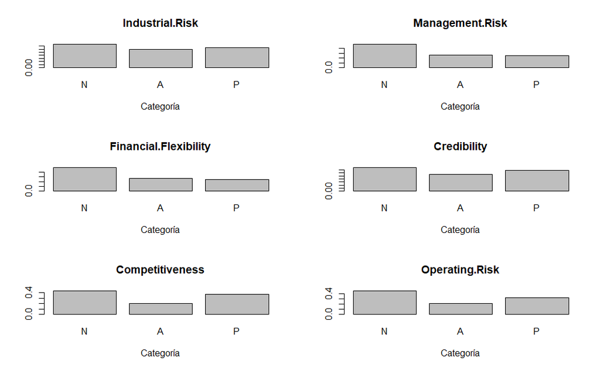

```r
par(mfrow=c(3, 2), mar=c(5, 4, 4, 2) + 0.1)

for( c in colnames(QB_dis1)[-length(colnames(QB_dis1))]){
  t <- table(QB_dis1[,c])/sum(table(QB_dis1[,c]))
  barplot(t, main=c, xlab="Categoría")

}
```

En cuanto a la variable clase, la distribución es la siguiente:

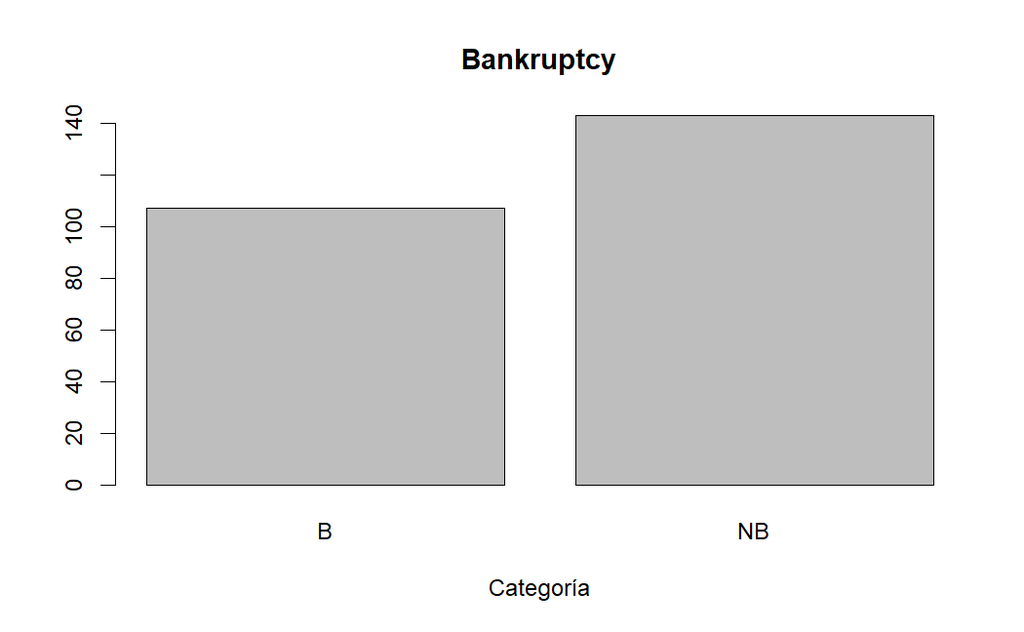

```r
barplot(table(QB_dis1$Bankruptcy), main="Bankruptcy", xlab="Categoría")
```

Repetimos el procedimiento para la segunda discretización:

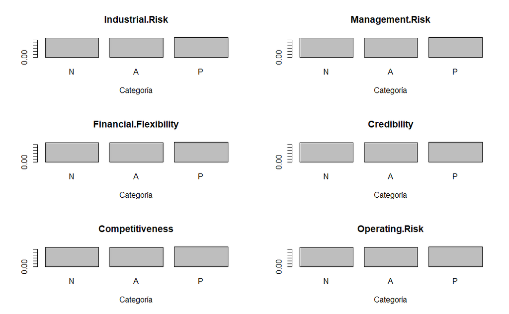

```r
par(mfrow=c(3, 2), mar=c(5, 4, 4, 2) + 0.1)

for( c in colnames(QB_dis2)[-length(colnames(QB_dis2))]){
  t <- table(QB_dis2[,c])/sum(table(QB_dis2[,c]))
  barplot(t, main=c, xlab="Categoría")

}
```

Dado que se ha hecho uso de la discretización usando el método de frecuencias, como era de esperar las categorías contienen cantidades de datos iguales para cada una de las varaibles

Para la tercera discretización, las categorías se distribuyen de la siguiente forma:

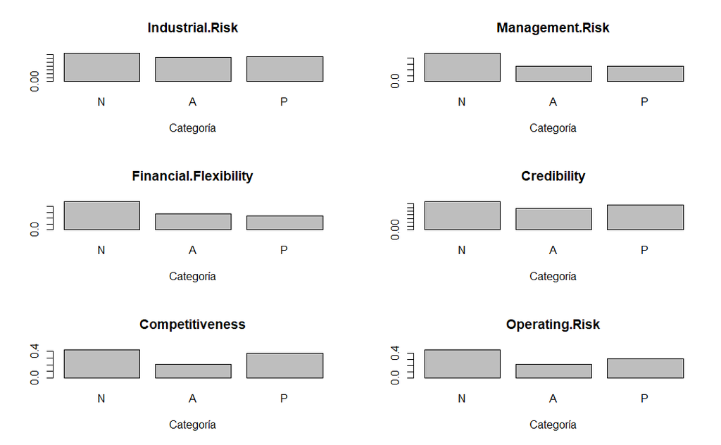

```r
par(mfrow=c(3, 2), mar=c(5, 4, 4, 2) + 0.1)

for( c in colnames(QB_dis3)[-length(colnames(QB_dis3))]){
  t <- table(QB_dis3[,c])/sum(table(QB_dis3[,c]))
  barplot(t, main=c, xlab="Categoría")

}
```

Describe, al menos, 2 conclusiones.

**>>><<<Conclusiones del análisis univariante…>>><<<**

- La selección de una discretización genera datos distribuidos de una forma muy diversa, por lo que una selección adecuada de la misma es importante para obtener buenos resultados. Cuestiones como el balanceo de frecuencias de cada uno de los valores de las variables generadas han de ser tenidas en cuenta para la elección de un método que genere la discretización.
- En nuestro problema, es la discretización basada en el método cluster la que parece generar mejores particiones a pesar de ser hacerse de forma no supervidada, ya las particiones generadas agrupan datos donde una clase aparece en proporción mucho mayor a la otra.

### Análisis bivariante de las variables Cualitativas

Obtén la relación entre las variables y la clase (ej. matrices de contingencia). Determina el grado de asociación (ej. chi2, CramerV, …) entre cada variable y la clase.

*Nota: La función PairApply de la librería DescTools permite calcular estadísticos para todos los pares. La función PlotCorr permite representar los resultados de PairApply.*

En primer lugar se toma la primera discretización.

En relación con la clase, se obtiene lo siguiente:

```r
#table(iris.discrete$Sepal.Length,iris.discrete$Species)


par(mfrow=c(3, 2), mar=c(5, 4, 4, 2) + 0.1)

for( c in colnames(QB_dis1)[-length(colnames(QB_dis1))]){
  t <- table(QB_dis1[,c],QB_dis1$Bankruptcy)
  cat("\nLas variable discretizada",c, "respecto a la objetivo se agrupa de la forma:")
  print(t)
  #barplot(t, main=c, xlab="Categoría")

}
```

```
Las variable discretizada Industrial.Risk respecto a la objetivo se agrupa de la forma:
     B NB
  N 55 39
  A 25 49
  P 27 55

Las variable discretizada Management.Risk respecto a la objetivo se agrupa de la forma:
     B NB
  N 73 48
  A 21 44
  P 13 51

Las variable discretizada Financial.Flexibility respecto a la objetivo se agrupa de la forma:
      B  NB
  N 102  21
  A   4  63
  P   1  59

Las variable discretizada Credibility respecto a la objetivo se agrupa de la forma:
     B NB
  N 87  9
  A 16 53
  P  4 81

Las variable discretizada Competitiveness respecto a la objetivo se agrupa de la forma:
      B  NB
  N 104   4
  A   3  47
  P   0  92

Las variable discretizada Operating.Risk respecto a la objetivo se agrupa de la forma:
     B NB
  N 64 50
  A 23 30
  P 20 63
```

Representando gráficamente, se obtiene:

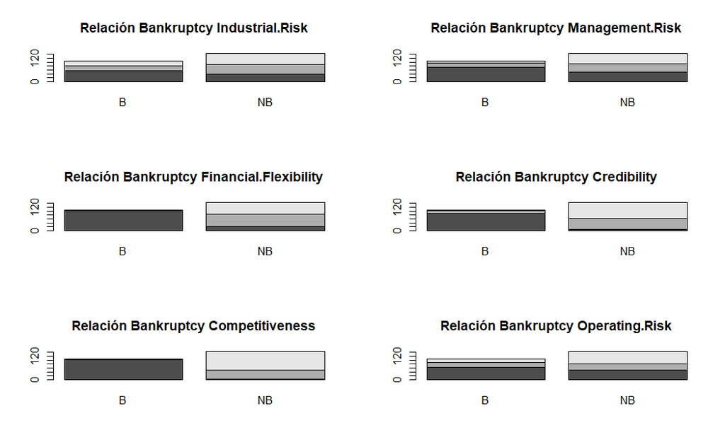

```r
par(mfrow=c(3, 2), mar=c(5, 4, 4, 2) + 0.1)

for( c in colnames(QB_dis1)[-length(colnames(QB_dis1))]){
  t <- table(QB_dis1[,c],QB_dis1$Bankruptcy)
  barplot(t, main = paste("Relación Bankruptcy ",c,sep = ""))


}
```

Para la discretización 2, los resultados han sido los siguientes:

```r
#table(iris.discrete$Sepal.Length,iris.discrete$Species)


par(mfrow=c(3, 2), mar=c(5, 4, 4, 2) + 0.1)

for( c in colnames(QB_dis1)[-length(colnames(QB_dis2))]){
  t <- table(QB_dis2[,c],QB_dis2$Bankruptcy)
  cat("\nLas variable discretizada",c, "respecto a la objetivo se agrupa de la forma:")
  print(t)
  #barplot(t, main=c, xlab="Categoría")

}
```

```
Las variable discretizada Industrial.Risk respecto a la objetivo se agrupa de la forma:
     B NB
  N 49 34
  A 31 52
  P 27 57

Las variable discretizada Management.Risk respecto a la objetivo se agrupa de la forma:
     B NB
  N 50 33
  A 41 42
  P 16 68

Las variable discretizada Financial.Flexibility respecto a la objetivo se agrupa de la forma:
     B NB
  N 70 13
  A 35 48
  P  2 82

Las variable discretizada Credibility respecto a la objetivo se agrupa de la forma:
     B NB
  N 78  5
  A 25 58
  P  4 80

Las variable discretizada Competitiveness respecto a la objetivo se agrupa de la forma:
     B NB
  N 83  0
  A 24 59
  P  0 84

Las variable discretizada Operating.Risk respecto a la objetivo se agrupa de la forma:
     B NB
  N 48 35
  A 38 45
  P 21 63
```

De nuevo, se representa de forma gráfica:

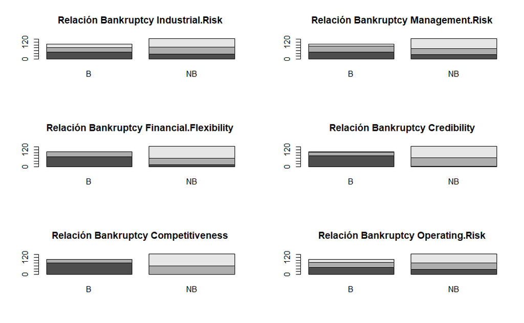

```r
par(mfrow=c(3, 2), mar=c(5, 4, 4, 2) + 0.1)

for( c in colnames(QB_dis2)[-length(colnames(QB_dis2))]){
  t <- table(QB_dis2[,c],QB_dis2$Bankruptcy)
  barplot(t, main = paste("Relación Bankruptcy ",c,sep = ""))


}
```

Para la tercera discretización, los resultados han sido:

```r
#table(iris.discrete$Sepal.Length,iris.discrete$Species)


par(mfrow=c(3, 2), mar=c(5, 4, 4, 2) + 0.1)

for( c in colnames(QB_dis3)[-length(colnames(QB_dis3))]){
  t <- table(QB_dis3[,c],QB_dis3$Bankruptcy)
  cat("\nLas variable discretizada",c, "respecto a la objetivo se agrupa de la forma:")
  print(t)
  #barplot(t, main=c, xlab="Categoría")

}
```

```
Las variable discretizada Industrial.Risk respecto a la objetivo se agrupa de la forma:
     B NB
  N 54 37
  A 27 52
  P 26 54

Las variable discretizada Management.Risk respecto a la objetivo se agrupa de la forma:
     B NB
  N 73 47
  A 21 45
  P 13 51

Las variable discretizada Financial.Flexibility respecto a la objetivo se agrupa de la forma:
      B  NB
  N 102  19
  A   4  66
  P   1  58

Las variable discretizada Credibility respecto a la objetivo se agrupa de la forma:
     B NB
  N 87  7
  A 16 57
  P  4 79

Las variable discretizada Competitiveness respecto a la objetivo se agrupa de la forma:
      B  NB
  N 104   1
  A   3  50
  P   0  92

Las variable discretizada Operating.Risk respecto a la objetivo se agrupa de la forma:
     B NB
  N 64 50
  A 24 32
  P 19 61
```

Se observa un desbalanceo de la variable objetivo para la clasificación, algo a tener en cuenta posteriormente

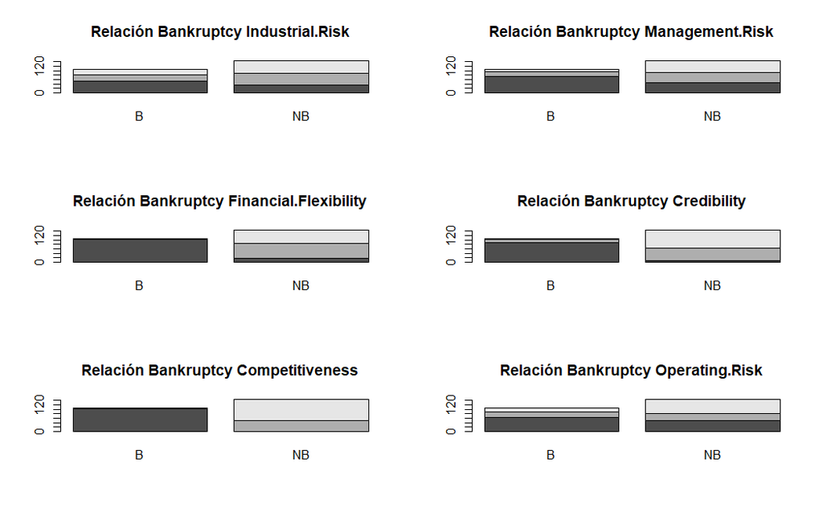

```r
par(mfrow=c(3, 2), mar=c(5, 4, 4, 2) + 0.1)

for( c in colnames(QB_dis3)[-length(colnames(QB_dis3))]){
  t <- table(QB_dis3[,c],QB_dis3$Bankruptcy)
  barplot(t, main = paste("Relación Bankruptcy ",c,sep = ""))


}
```

En segunda instancia, pasamos a estudiar las relaciones entre varaibles en cada una de las discretizaciones:

```r
library(DescTools)


matriz_contingencia <- PairApply(QB_dis1, FUN = chisq.test)
matriz_contingencia
```

[output not shown]

```r
#PlotCorr(matriz_contingencia)
```

Contrasta los resultados con los gráficos de Mosaico de los casos más relevantes.

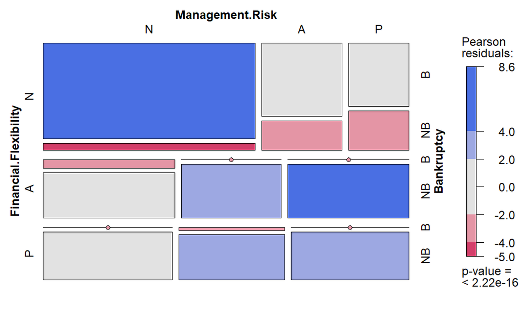

```r
library(vcd)
mosaic(formula=~Financial.Flexibility+Management.Risk+Bankruptcy,data=QB_dis1, shade=TRUE)
```

## Reglas de Asociación

Transforma el `data.frame` en *transactions* con el nombre `QBt` y analízalas con `summary`. Se realiza uno para cada una de las discretizaciones realizadas.

Para la primera discretización, se tiene:

```r
#solution

library(arules)
library(arulesCBA)

QBt1 <- CBA(Bankruptcy~. , data = QB_dis1)

summary(QBt1)
```

```
               Length Class   Mode
formula         3     formula call
rules          13     rules   S4
default         1     factor  numeric
weights         0     -none-  NULL
bias            0     -none-  NULL
method          1     -none-  character
model           1     -none-  list
discretization  7     -none-  list
description     1     -none-  character
```

```r
QBt1$rules
```

```
set of 13 rules
```

Obtén las reglas de asociación que tienen, al menos, un `support` del 10% y una `confidence` del 100%. ¿Cuántas reglas se obtienen?

```r
#solution

modeloCBA1 <- CBA(Bankruptcy~. , data = QB_dis1, supp = 0.1, conf =1.0 )

summary(modeloCBA1)
```

```
               Length Class   Mode
formula         3     formula call
rules          13     rules   S4
default         1     factor  numeric
weights         0     -none-  NULL
bias            0     -none-  NULL
method          1     -none-  character
model           1     -none-  list
discretization  7     -none-  list
description     1     -none-  character
```

```r
modeloCBA1$rules
```

```
set of 13 rules
```

Para la primera discretización, se obienen un total de 13 reglas, especialmente debido al support bajo considerado, que de aumentarse reduciría el número de reglas.

Se pueden obtener las 5 primeras de la siguiente forma:

```r
table(inspect(head(sort(modeloCBA1$rules,by="support"),5)))
```

|  | lhs |  | rhs | support | confidence | coverage | lift | count | size | coveredTransactions | totalErrors |
| --- | --- | --- | --- | --- | --- | --- | --- | --- | --- | --- | --- |
| [1] | {} | => | {Bankruptcy=NB} | 0.572 | 0.572 | 1.000 | 1.000000 | 250 | 1 | 3 | 1 |
| [2] | {Financial.Flexibility=N, Competitiveness=N} | => | {Bankruptcy=B} | 0.396 | 1.000 | 0.396 | 2.336449 | 99 | 3 | 99 | 8 |
| [3] | {Competitiveness=P} | => | {Bankruptcy=NB} | 0.368 | 1.000 | 0.368 | 1.748252 | 92 | 2 | 92 | 8 |
| [4] | {Credibility=N, Competitiveness=N} | => | {Bankruptcy=B} | 0.336 | 1.000 | 0.336 | 2.336449 | 84 | 3 | 4 | 4 |
| [5] | {Financial.Flexibility=A, Credibility=P} | => | {Bankruptcy=NB} | 0.148 | 1.000 | 0.148 | 1.748252 | 37 | 3 | 17 | 4 |

[output not shown]

[output cut: 1946 more lines]

[output not shown]

Para la discretización 2 se obtiene lo siguiente:

```r
#solution

modeloCBA2 <- CBA(Bankruptcy~. , data = QB_dis2, supp = 0.1, conf =1. )

summary(modeloCBA2)
```

```
               Length Class   Mode
formula         3     formula call
rules          10     rules   S4
default         1     factor  numeric
weights         0     -none-  NULL
bias            0     -none-  NULL
method          1     -none-  character
model           1     -none-  list
discretization  7     -none-  list
description     1     -none-  character
```

```r
modeloCBA2$rules
```

```
set of 10 rules
```

En este caso, por la discretización considerada, el número de reglas es de 10.

Por último, para la tercera discretización se obtiene:

```r
#solution

modeloCBA3 <- CBA(Bankruptcy~. , data = QB_dis3, supp = 0.1, conf =1 )

summary(modeloCBA3)
```

```
               Length Class   Mode
formula         3     formula call
rules          13     rules   S4
default         1     factor  numeric
weights         0     -none-  NULL
bias            0     -none-  NULL
method          1     -none-  character
model           1     -none-  list
discretization  7     -none-  list
description     1     -none-  character
```

```r
modeloCBA3$rules
```

```
set of 13 rules
```

Para esta última el número de reglas obtenidas es el mismo que para la primera discretización, es decir, hay un total de 13 reglas con soporte 0.1 y confianza 1.

Muestra las 3 primeras reglas ordenadas por `lift`.

En el conjunto de reglas obtenido mediante la primera discretización se obtiene:

```r
#solution

table(inspect(head(sort(modeloCBA1$rules, by="lift"),3)))
```

|  | lhs |  | rhs | support | confidence | coverage | lift | count | size | coveredTransactions | totalErrors |
| --- | --- | --- | --- | --- | --- | --- | --- | --- | --- | --- | --- |
| [1] | {Financial.Flexibility=N, Competitiveness=N} | => | {Bankruptcy=B} | 0.396 | 1 | 0.396 | 2.336449 | 99 | 3 | 99 | 8 |
| [2] | {Credibility=N, Competitiveness=N} | => | {Bankruptcy=B} | 0.336 | 1 | 0.336 | 2.336449 | 84 | 3 | 4 | 4 |
| [3] | {Industrial.Risk=P, Financial.Flexibility=N, Credibility=N} | => | {Bankruptcy=B} | 0.104 | 1 | 0.104 | 2.336449 | 26 | 4 | 3 | 1 |

[output not shown]

[output cut: 2616 more lines]

[output not shown]

```r
## ESTURIAR REGLA 3 TODO

table(inspect(head(sort(modeloCBA2$rules, by="lift"),5)))
```

|  | lhs |  | rhs | support | confidence | coverage | lift | count | size | coveredTransactions | totalErrors |
| --- | --- | --- | --- | --- | --- | --- | --- | --- | --- | --- | --- |
| [1] | {Competitiveness=N} | => | {Bankruptcy=B} | 0.332 | 1 | 0.332 | 2.336449 | 83 | 2 | 83 | 24 |
| [2] | {Industrial.Risk=N, Credibility=N} | => | {Bankruptcy=B} | 0.128 | 1 | 0.128 | 2.336449 | 32 | 3 | 5 | 16 |
| [3] | {Competitiveness=P} | => | {Bankruptcy=NB} | 0.336 | 1 | 0.336 | 1.748252 | 84 | 2 | 84 | 59 |
| [4] | {Financial.Flexibility=P, Credibility=P} | => | {Bankruptcy=NB} | 0.168 | 1 | 0.168 | 1.748252 | 42 | 3 | 17 | 24 |
| [5] | {Industrial.Risk=P, Financial.Flexibility=P} | => | {Bankruptcy=NB} | 0.160 | 1 | 0.160 | 1.748252 | 40 | 3 | 9 | 24 |

[output not shown]

[output cut: 1946 more lines]

[output not shown]

```r
table(inspect(head(sort(modeloCBA3$rules, by="lift"),3)))
```

|  | lhs |  | rhs | support | confidence | coverage | lift | count | size | coveredTransactions | totalErrors |
| --- | --- | --- | --- | --- | --- | --- | --- | --- | --- | --- | --- |
| [1] | {Financial.Flexibility=N, Competitiveness=N} | => | {Bankruptcy=B} | 0.396 | 1 | 0.396 | 2.336449 | 99 | 3 | 99 | 8 |
| [2] | {Credibility=N, Competitiveness=N} | => | {Bankruptcy=B} | 0.336 | 1 | 0.336 | 2.336449 | 84 | 3 | 4 | 4 |
| [3] | {Industrial.Risk=N, Competitiveness=N} | => | {Bankruptcy=B} | 0.216 | 1 | 0.216 | 2.336449 | 54 | 3 | 1 | 3 |

[output not shown]

[output cut: 1888 more lines]

[output not shown]

Obtén las reglas de asociación que tengan como **ANTECEDENTE** `Bankruptcy=B` . Reduce el número de reglas con las condiciones `lift>2 & count>50`. ¿Observas algún patrón/curiosidad en estas reglas?

*Nota: Representar las reglas ayuda en la interpretación.*

```r
library(arulesViz)
```

Para la primera discretización se tiene:

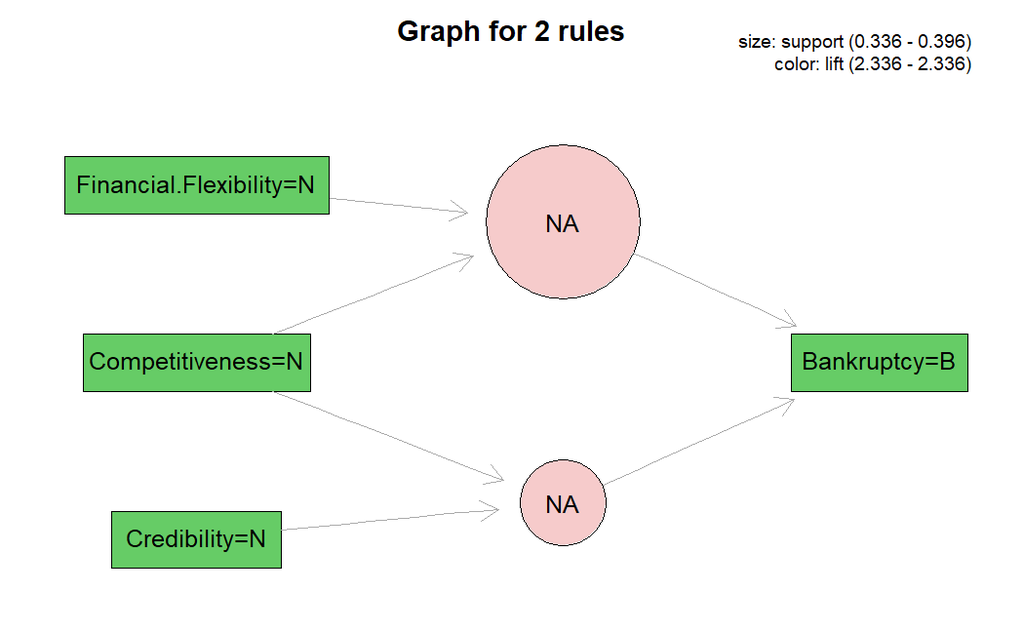

```r
modeloCBA1 <- CBA(Bankruptcy~. , data = QB_dis1, supp = 0.1, conf =1.0 )
reglas <- subset(modeloCBA1$rules,lift>2)
reglas <- subset(reglas,count>50)
reglas <- subset(reglas,subset=rhs %pin% "Bankruptcy=B")

plot(reglas, method="graph", engine="graphviz")
```

Los resultados obtenidos por la primera discretización son curiosos, ya que reflejan que la falta de competitividad, relacionada con otros factores como la no credibilidad, esta relacionada con la bancarrota, aunque parezca contraproducente.

Del mismo modo, se repite el procedimiento con la discretización número 2:

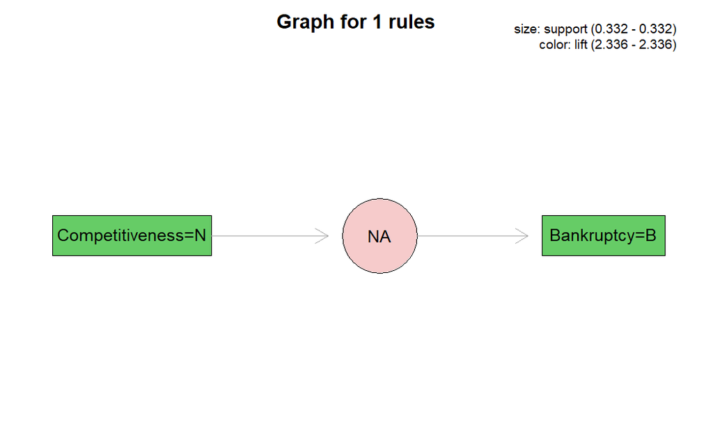

```r
modeloCBA2 <- CBA(Bankruptcy~. , data = QB_dis2, supp = 0.1, conf =1.0 )
reglas <- subset(modeloCBA2$rules,lift>2)
reglas <- subset(reglas,count>50)
reglas <- subset(reglas,subset=rhs %pin% "Bankruptcy=B")

plot(reglas, method="graph", engine="graphviz")
```

De nuevo, refleja que la falta de competencia implica bancarrota.

Por último, se repite el procedimiento con la tercera discretización:

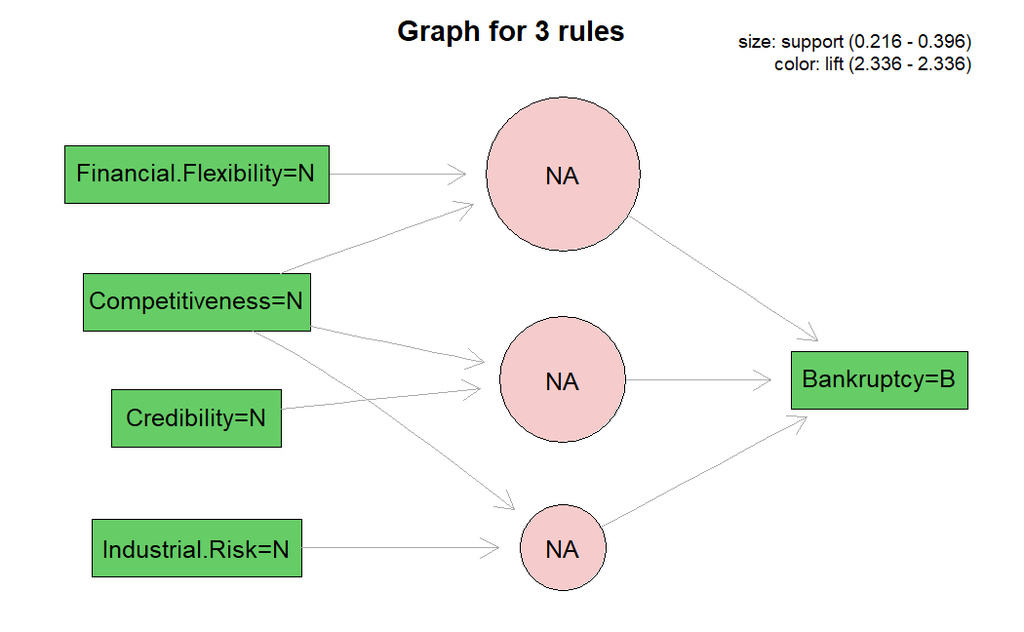

```r
modeloCBA3 <- CBA(Bankruptcy~. , data = QB_dis3, supp = 0.1, conf =1.0 )
reglas <- subset(modeloCBA3$rules,lift>2)
reglas <- subset(reglas,count>50)
reglas <- subset(reglas,subset=rhs %pin% "Bankruptcy=B")

plot(reglas, method="graph", engine="graphviz")
```

En este caso se obtiene un mayor número de variables, pero las reglas formadas se asemejan bastante a las obtenidas por las otras discretizaciones. Además destaca la competitividad, que aparece en las 3 reglas conformadas.

Obtén las reglas de asociación en las que **no** aparezca la variable`Bankruptcy` (ni en el antecedente ni en la consecuencia). Representa las reglas. ¿Para qué sirven estas reglas/grafo si no aparece la variable objetivo?

```r
modeloCBA1 <- CBA(Bankruptcy~. , data = QB_dis1, supp = 0.1, conf =1 )

reglas <- subset(modeloCBA1$rules,!(rhs %pin% "Bankruptcy="))

if(length(reglas)==0){
  print("No hay reglas que cumplan la condición")

}else{
  plot(reglas, method="graph", engine="graphviz")
}
```

```
[1] "No hay reglas que cumplan la condición"
```

La obtención de estas reglas nos permite obtener relaciones entre las variables. Estos patrones pueden simplificar las reglas, en especial si las relaciones entre variables son muy fuertes, de forma que se pueden obtener modelos con reglas mucho más simples con rendimientos similares.

## Predicción con reglas de asociación

Desarrolla un modelo de clasificación basado en reglas de asociación para estimar la Bancarrota. Comprueba la bondad del modelo (sensibilidad y especificidad) dividiendo el conjunto de datos en Entrenamiento 80% y Test 20%. Utiliza la función `createDataPartition` y `confusionMatrix` del paquete `caret`.

En primer lugar, se prueba la discretización

```r
set.seed(666)

library(caret, quietly = TRUE)
trainIndex <- createDataPartition(QB_dis1$Bankruptcy,p = 0.8 , list = F)

train_dis1 <- QB_dis1[trainIndex,]

test_dis1<- QB_dis1[-trainIndex,]
```

```r
# Se crea una función que se usará para generar modelos en función de los hiperparámetros deseados y los datos pasados

modeloReglas <- function(data, conf, sup){

  modeloCBA <- CBA(Bankruptcy~. , data = data, sup = sup, conf =conf)

  return(modeloCBA)


}
```

```r
modelo <- modeloReglas(train_dis1,conf = 1, sup = 0.1)

#plot(modelo$rules, method="graph", engine="graphviz")

predictClassTrain <- predict(modelo, train_dis1)

confusionMatrix(predictClassTrain,train_dis1$Bankruptcy)
```

```
Confusion Matrix and Statistics

          Reference
Prediction   B  NB
        B   85   0
        NB   1 115

               Accuracy : 0.995
                 95% CI : (0.9726, 0.9999)
    No Information Rate : 0.5721
    P-Value [Acc > NIR] : <2e-16

                  Kappa : 0.9898

 Mcnemar's Test P-Value : 1

            Sensitivity : 0.9884
            Specificity : 1.0000
         Pos Pred Value : 1.0000
         Neg Pred Value : 0.9914
             Prevalence : 0.4279
         Detection Rate : 0.4229
   Detection Prevalence : 0.4229
      Balanced Accuracy : 0.9942

       'Positive' Class : B
```

Se observa que, para el conjunto de entrenamiento, la clasificación con los parametros iniciales y la discretización 1 da muy buenos resultados, incluido tomando como referencia metricas como el TPR y FPR. Ahora se estudia su capacidad de predicción en test, para saber si generaliza o sobreajusta al primero:

```r
predictClassTest <- predict(modelo, test_dis1)

confusionMatrix(predictClassTest,test_dis1$Bankruptcy)
```

```
Confusion Matrix and Statistics

          Reference
Prediction  B NB
        B  21  0
        NB  0 28

               Accuracy : 1
                 95% CI : (0.9275, 1)
    No Information Rate : 0.5714
    P-Value [Acc > NIR] : 1.233e-12

                  Kappa : 1

 Mcnemar's Test P-Value : NA

            Sensitivity : 1.0000
            Specificity : 1.0000
         Pos Pred Value : 1.0000
         Neg Pred Value : 1.0000
             Prevalence : 0.4286
         Detection Rate : 0.4286
   Detection Prevalence : 0.4286
      Balanced Accuracy : 1.0000

       'Positive' Class : B
```

Como resultado el modelo logra predecir todas las instancias del conjunto de test de forma correcta con los hiperparámetros seleccionados en primer momento. Estudiamos las reglas a fondo que logran el buen funcionamiento del mismo:

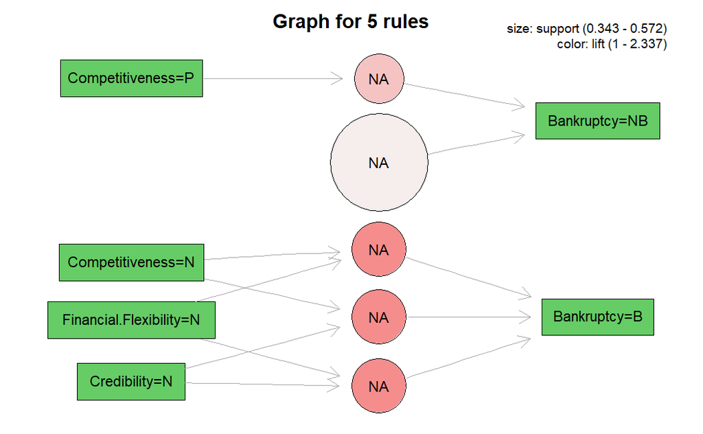

```r
plot(modelo$rules, method="graph", engine="graphviz")
```

Reflexiones sobre el modelo basado en reglas:

**>>><<<Conclusiones del modelo basado en reglas…>>><<<**

El modelo obtenido es capaz de generalizar, obteniendo buenos resultados tanto para train como para test.

Una de las principales ventajas que encontramos en el uso de un modelo basado en reglas es su gran interpretabilidad, algo importante cuando necesitamos conocer de forma exacta que lleva al modelo a dar la respuesta.

¿has utilizado todas las variables en el modelo y por qué?

En las reglas obtenidas por el modelo no se hacen uso de todas las reglas, algo que evita la generalización del mismo, ya que de no hacerse se incrementaría demasiado la varainza del mismo, que resultaría en una degradación del rendimiento.

¿has seleccionado reglas y por qué? ¿en base a qué criterio?

La selección de reglas se ha obtenido mediante la selección de los hiperparámetros support y confidence para su entrenamiento. En este caso el uso de un support de 0.1 y una confianza de 1 es la que nos ha permitido obtener buenos resultados tanto en train como en test para este conjunto de datos.